# Regression

Elara

2016年5月4日

# 线性回归

## 线性模型

$$\begin{equation}
Y_i=e^{\beta_1+\beta_2X_i+\epsilon_i} \\
Y_i=\frac{1}{e^{\beta_1+\beta_2X_i+\epsilon_i}} \\
Y_i=\beta_1+(0.75-\beta_1)e^{-\beta_2(X_i-2)}+\epsilon_i \\
Y_i=\beta_1+\beta_2^{3}X_i+\epsilon_i \\
Y_i=\beta_1+\beta_2(\frac{1}{X_i})+\epsilon_i \\
\end{equation}$$

1. 125是线性模型
2. 没有截距项的时候R2不能用。
3. 无法把方差分解成可解释和不可解释部分。
4. 即使截距项不显著也不能去掉。去掉的话一定过原点。
5. R2受到模型变量数目影响。要用adj.R2

## LM线性模型估计OLS

```r
#Y X 线性
options(digits=3)
fit <- lm(weight ~ height, data = women)
summary(fit)
```

```
##
## Call:
## lm(formula = weight ~ height, data = women)
##
## Residuals:
##    Min     1Q Median     3Q    Max
## -1.733 -1.133 -0.383  0.742  3.117
##
## Coefficients:
##             Estimate Std. Error t value Pr(>|t|)
## (Intercept) -87.5167     5.9369   -14.7  1.7e-09 ***
## height        3.4500     0.0911    37.9  1.1e-14 ***
## ---
## Signif. codes:  0 '***' 0.001 '**' 0.01 '*' 0.05 '.' 0.1 ' ' 1
##
## Residual standard error: 1.53 on 13 degrees of freedom
## Multiple R-squared:  0.991,  Adjusted R-squared:  0.99
## F-statistic: 1.43e+03 on 1 and 13 DF,  p-value: 1.09e-14
```

```r
coefficients(fit)
```

```
## (Intercept)      height
##      -87.52        3.45
```

```r
fitted(fit)
```

```
##   1   2   3   4   5   6   7   8   9  10  11  12  13  14  15
## 113 116 119 123 126 130 133 137 140 144 147 151 154 157 161
```

```r
residuals(fit)
```

```
##       1       2       3       4       5       6       7       8       9
##  2.4167  0.9667  0.5167  0.0667 -0.3833 -0.8333 -1.2833 -1.7333 -1.1833
##      10      11      12      13      14      15
## -1.6333 -1.0833 -0.5333  0.0167  1.5667  3.1167
```

```r
deviance(fit)
```

```
## [1] 30.2
```

```r
#置信区间0.99
confint(fit,level=0.99)
```

```
##               0.5 % 99.5 %
## (Intercept) -105.40 -69.63
## height         3.18   3.72
```

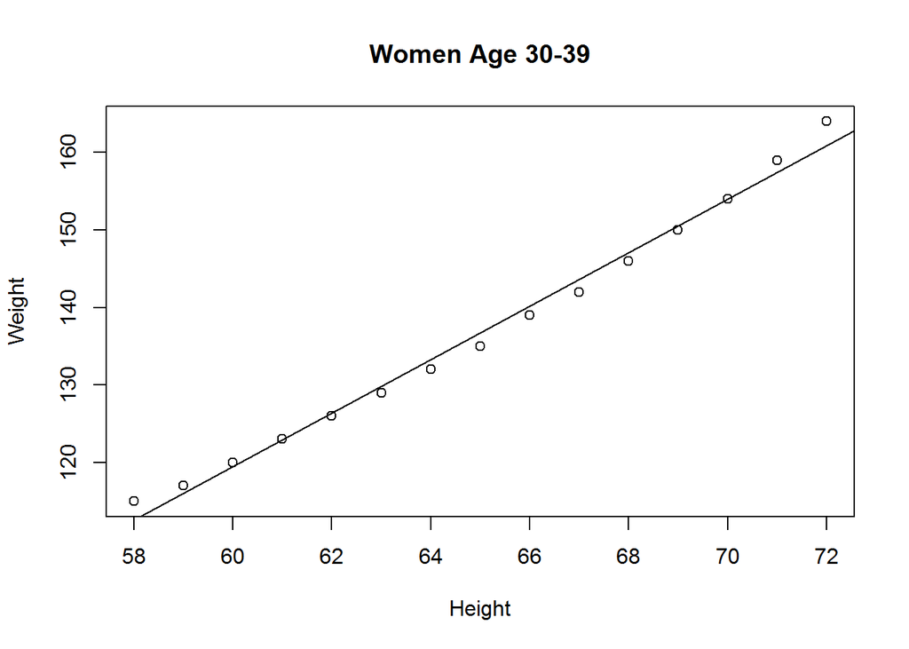

```r
plot(women$height,women$weight,main="Women Age 30-39",xlab="Height",ylab="Weight")

abline(fit)
```

```r
#x和y非线性
fit2 <- lm(weight ~ height + I(height^2), data=women)
summary(fit2)
```

```
##
## Call:
## lm(formula = weight ~ height + I(height^2), data = women)
##
## Residuals:
##     Min      1Q  Median      3Q     Max
## -0.5094 -0.2961 -0.0094  0.2862  0.5971
##
## Coefficients:
##              Estimate Std. Error t value Pr(>|t|)
## (Intercept) 261.87818   25.19677   10.39  2.4e-07 ***
## height       -7.34832    0.77769   -9.45  6.6e-07 ***
## I(height^2)   0.08306    0.00598   13.89  9.3e-09 ***
## ---
## Signif. codes:  0 '***' 0.001 '**' 0.01 '*' 0.05 '.' 0.1 ' ' 1
##
## Residual standard error: 0.384 on 12 degrees of freedom
## Multiple R-squared:  0.999,  Adjusted R-squared:  0.999
## F-statistic: 1.14e+04 on 2 and 12 DF,  p-value: <2e-16
```

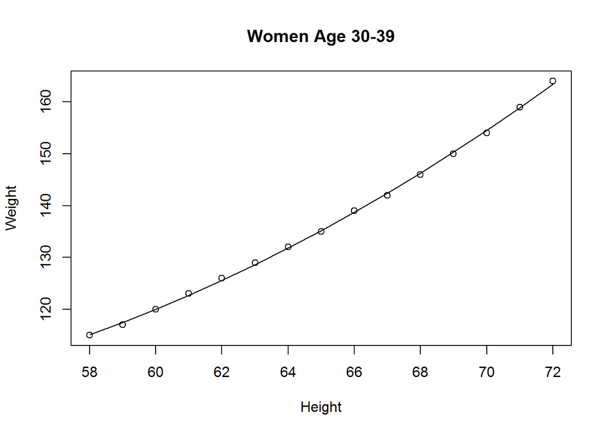

```r
plot(women$height, women$weight, main = "Women Age 30-39",
xlab = "Height", ylab = "Weight")
lines(women$height, fitted(fit2))
```

```r
Anscombe<-data.frame(
X =c(10.0, 8.0, 13.0, 9.0, 11.0, 14.0, 6.0, 4.0, 12.0, 7.0, 5.0),
Y1=c(8.04, 6.95, 7.58, 8.81, 8.33, 9.96, 7.24, 4.26, 10.84, 4.82, 5.68),
Y2=c(9.14, 8.14, 8.74, 8.77, 9.26, 8.10, 6.13, 3.10, 9.13, 7.26, 4.74),
Y3=c(7.46, 6.77, 12.74, 7.11, 7.81, 8.84, 6.08, 5.39, 8.15, 6.44, 5.73),
X4=c(rep(8,7), 19, rep(8,3)),
Y4=c(6.58, 5.76, 7.71, 8.84, 8.47, 7.04, 5.25, 12.50, 5.56, 7.91, 6.89)
)
summary(lm(Y1~X, data=Anscombe))
```

```
##
## Call:
## lm(formula = Y1 ~ X, data = Anscombe)
##
## Residuals:
##     Min      1Q  Median      3Q     Max
## -1.9213 -0.4558 -0.0414  0.7094  1.8388
##
## Coefficients:
##             Estimate Std. Error t value Pr(>|t|)
## (Intercept)    3.000      1.125    2.67   0.0257 *
## X              0.500      0.118    4.24   0.0022 **
## ---
## Signif. codes:  0 '***' 0.001 '**' 0.01 '*' 0.05 '.' 0.1 ' ' 1
##
## Residual standard error: 1.24 on 9 degrees of freedom
## Multiple R-squared:  0.667,  Adjusted R-squared:  0.629
## F-statistic:   18 on 1 and 9 DF,  p-value: 0.00217
```

```r
summary(lm(Y2~X, data=Anscombe))
```

```
##
## Call:
## lm(formula = Y2 ~ X, data = Anscombe)
##
## Residuals:
##    Min     1Q Median     3Q    Max
## -1.901 -0.761  0.129  0.949  1.269
##
## Coefficients:
##             Estimate Std. Error t value Pr(>|t|)
## (Intercept)    3.001      1.125    2.67   0.0258 *
## X              0.500      0.118    4.24   0.0022 **
## ---
## Signif. codes:  0 '***' 0.001 '**' 0.01 '*' 0.05 '.' 0.1 ' ' 1
##
## Residual standard error: 1.24 on 9 degrees of freedom
## Multiple R-squared:  0.666,  Adjusted R-squared:  0.629
## F-statistic:   18 on 1 and 9 DF,  p-value: 0.00218
```

```r
summary(lm(Y3~X, data=Anscombe))
```

```
##
## Call:
## lm(formula = Y3 ~ X, data = Anscombe)
##
## Residuals:
##    Min     1Q Median     3Q    Max
## -1.159 -0.616 -0.232  0.151  3.241
##
## Coefficients:
##             Estimate Std. Error t value Pr(>|t|)
## (Intercept)    3.008      1.124    2.67   0.0254 *
## X              0.499      0.118    4.24   0.0022 **
## ---
## Signif. codes:  0 '***' 0.001 '**' 0.01 '*' 0.05 '.' 0.1 ' ' 1
##
## Residual standard error: 1.24 on 9 degrees of freedom
## Multiple R-squared:  0.666,  Adjusted R-squared:  0.629
## F-statistic: 17.9 on 1 and 9 DF,  p-value: 0.00218
```

```r
summary(lm(Y4~X4,data=Anscombe))
```

```
##
## Call:
## lm(formula = Y4 ~ X4, data = Anscombe)
##
## Residuals:
##    Min     1Q Median     3Q    Max
## -1.751 -0.831  0.000  0.809  1.839
##
## Coefficients:
##             Estimate Std. Error t value Pr(>|t|)
## (Intercept)    3.002      1.124    2.67   0.0256 *
## X4             0.500      0.118    4.24   0.0022 **
## ---
## Signif. codes:  0 '***' 0.001 '**' 0.01 '*' 0.05 '.' 0.1 ' ' 1
##
## Residual standard error: 1.24 on 9 degrees of freedom
## Multiple R-squared:  0.667,  Adjusted R-squared:  0.63
## F-statistic:   18 on 1 and 9 DF,  p-value: 0.00216
```

```r
head(Anscombe)
```

```
##    X   Y1   Y2    Y3 X4   Y4
## 1 10 8.04 9.14  7.46  8 6.58
## 2  8 6.95 8.14  6.77  8 5.76
## 3 13 7.58 8.74 12.74  8 7.71
## 4  9 8.81 8.77  7.11  8 8.84
## 5 11 8.33 9.26  7.81  8 8.47
## 6 14 9.96 8.10  8.84  8 7.04
```

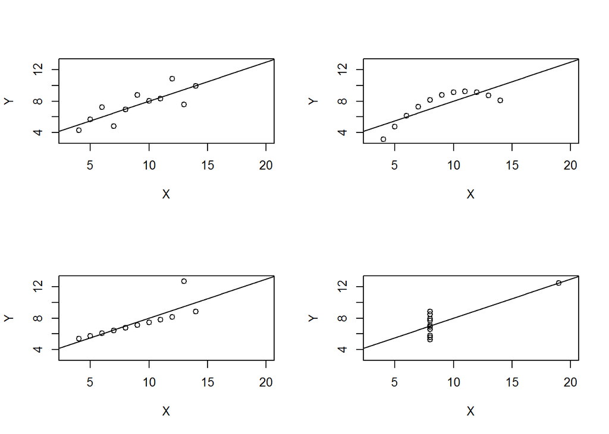

```r
attach(Anscombe)
par(mfrow = c(2,2))
plot(c(3,20), c(3,13), type="n", xlab = "X", ylab = "Y"); points(X,Y1); abline(lm(Y1~X))
plot(c(3,20), c(3,13), type="n", xlab = "X", ylab = "Y"); points(X,Y2); abline(lm(Y2~X))
plot(c(3,20), c(3,13), type="n", xlab = "X", ylab = "Y"); points(X,Y3); abline(lm(Y3~X))
plot(c(3,20), c(3,13), type="n", xlab = "X", ylab = "Y"); points(X4,Y4); abline(lm(Y4~X4))
```

系数都是3和0.5并且都显著。可是作图结果形状完全不一致2是曲线3有异常值4除了一个点以外都是同一个竖线上

```r
#1没有问题
par(mfrow = c(1,1))
#2是个曲线，加入平方拟合
X2<-X^2
#存放用平方拟合的系数
lm2.sol<-lm(Y2~X+X2)
summary(lm2.sol)
```

```
##
## Call:
## lm(formula = Y2 ~ X + X2)
##
## Residuals:
##       Min        1Q    Median        3Q       Max
## -0.001329 -0.001189 -0.000629  0.000874  0.002378
##
## Coefficients:
##              Estimate Std. Error t value Pr(>|t|)
## (Intercept) -6.00e+00   4.33e-03   -1385   <2e-16 ***
## X            2.78e+00   1.04e-03    2674   <2e-16 ***
## X2          -1.27e-01   5.71e-05   -2219   <2e-16 ***
## ---
## Signif. codes:  0 '***' 0.001 '**' 0.01 '*' 0.05 '.' 0.1 ' ' 1
##
## Residual standard error: 0.00167 on 8 degrees of freedom
## Multiple R-squared:     1,   Adjusted R-squared:     1
## F-statistic: 7.38e+06 on 2 and 8 DF,  p-value: <2e-16
```

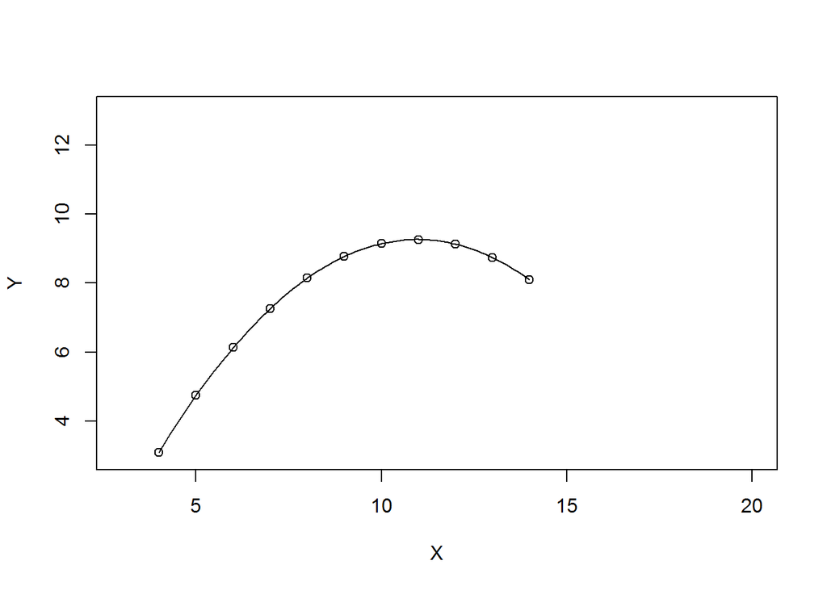

```r
#作图用x
x<-seq(min(X), max(X), by=0.1)
#作图用系数
b<-coef(lm2.sol)
y<-b[1]+b[2]*x+b[3]*x^2
plot(c(3,20), c(3,13), type="n", xlab = "X", ylab = "Y")
#plot原图
points(X,Y2)
lines(x,y)
```

```r
#3
#去掉第三个（异常值）
i<-1:11; Y31<-Y3[i!=3]; X3<-X[i!=3]
lm3.sol<-lm(Y31~X3)
summary(lm3.sol)
```

```
##
## Call:
## lm(formula = Y31 ~ X3)
##
## Residuals:
##       Min        1Q    Median        3Q       Max
## -0.006017 -0.001212 -0.001017 -0.000823  0.014069
##
## Coefficients:
##             Estimate Std. Error t value Pr(>|t|)
## (Intercept) 4.010628   0.005711     702   <2e-16 ***
## X3          0.345043   0.000626     551   <2e-16 ***
## ---
## Signif. codes:  0 '***' 0.001 '**' 0.01 '*' 0.05 '.' 0.1 ' ' 1
##
## Residual standard error: 0.00602 on 8 degrees of freedom
## Multiple R-squared:     1,   Adjusted R-squared:     1
## F-statistic: 3.04e+05 on 1 and 8 DF,  p-value: <2e-16
```

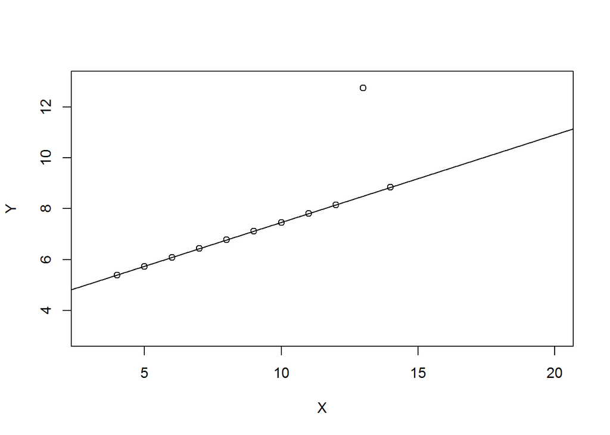

```r
plot(c(3,20), c(3,13), type="n", xlab = "X", ylab = "Y")
points(X,Y3)
abline(lm3.sol)
```

```r
detach(Anscombe)
```

## 异常值检测

1.diffits指标

$$DFFITS=\frac{\hat{y_i}-\hat{y_{i(i)}}}{s_(i)\sqrt{h_{ii}}}\sqrt{h_{ii}/(1-h_{ii})}$$

h是帽子矩阵，y尖=hy

```r
attach(Anscombe)
p<-1; n<-length(X);d<-dffits(lm(Y3~X, data=Anscombe))
cf<-1:n; cf[d>2*sqrt((p+1)/n)]
```

```
## [1] 3
```

```r
#取出1到n里面满足dffits大于2根号（（p+1）/n）
detach(Anscombe)
```

返回了异常值位置3

2.Cook’s distance

$$D_i=\frac{(\hat{\beta}-\hat{\beta}^{(-i)})^{T}(X^{T}X)(\hat{\beta}-\hat{\beta}^{(-i)})}{(1+p)s^{2}}$$

```r
Fit<-lm(Y3~X, data=Anscombe)
cooks.distance(Fit)
```

```
##        1        2        3        4        5        6        7        8
## 0.011831 0.002183 1.392828 0.005525 0.026072 0.300634 0.000480 0.033194
##        9       10       11
## 0.059650 0.000218 0.006752
```

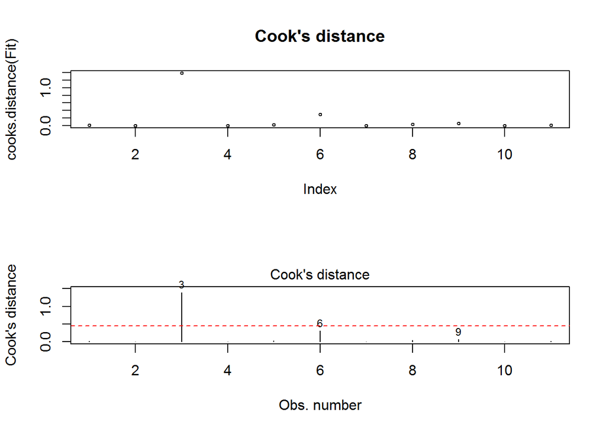

```r
par(mfrow=c(2,1))
#散点图
plot(cooks.distance(Fit),main="Cook's distance",cex=0.5)
#线图，红线表示警戒线
Np<-length(coefficients(Fit))-1#变量数
N<-length(fitted(Fit))
#红线算法
CutLevel<-4/(N-Np-1)
plot(Fit,which=4)
abline(CutLevel,0,lty=2,col="red")
```

summary

```r
#可以直接算dffit和cook，有问题的会带星号
influence.measures(lm(Y3~X, data=Anscombe))
```

```
## Influence measures of
##   lm(formula = Y3 ~ X, data = Anscombe) :
##
##       dfb.1_     dfb.X    dffit    cov.r   cook.d    hat inf
## 1  -4.64e-03 -4.43e-02  -0.1468 1.34e+00 0.011831 0.1000
## 2  -3.75e-02  1.88e-02  -0.0624 1.39e+00 0.002183 0.1000
## 3  -1.83e+02  2.69e+02 342.7851 7.36e-10 1.392828 0.2364   *
## 4  -3.31e-02 -2.66e-18  -0.0997 1.36e+00 0.005525 0.0909
## 5   4.92e-02 -1.17e-01  -0.2197 1.34e+00 0.026072 0.1273
## 6   4.90e-01 -6.67e-01  -0.7898 1.36e+00 0.300634 0.3182
## 7   2.60e-02 -2.01e-02   0.0292 1.53e+00 0.000480 0.1727
## 8   2.39e-01 -2.07e-01   0.2449 1.80e+00 0.033194 0.3182   *
## 9   1.38e-01 -2.32e-01  -0.3365 1.34e+00 0.059650 0.1727
## 10 -1.54e-02  1.05e-02  -0.0197 1.45e+00 0.000218 0.1273
## 11  1.04e-01 -8.62e-02   0.1098 1.64e+00 0.006752 0.2364
```

## 最大似然估计

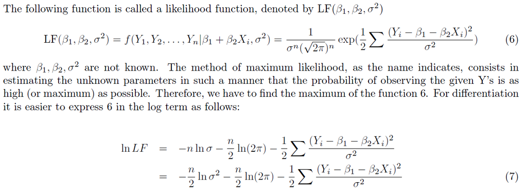

m

```r
library("maxLik")
indfood<-read.csv(file="C:\\Users\\44180\\Documents\\sourcetree\\elara7\\soe\\Rmarkdown\\Chap_9\\Indfood.csv")
#抽取数据
foodexp<-indfood[,1]
totalexp<-indfood[,2]
#OLS回归
lm_r <- lm(foodexp~totalexp)
summary(lm_r)
```

```
##
## Call:
## lm(formula = foodexp ~ totalexp)
##
## Residuals:
##     Min      1Q  Median      3Q     Max
## -153.77  -46.61    7.75   37.70  171.59
##
## Coefficients:
##             Estimate Std. Error t value Pr(>|t|)
## (Intercept)  94.2088    50.8563    1.85     0.07 .
## totalexp      0.4368     0.0783    5.58  8.5e-07 ***
## ---
## Signif. codes:  0 '***' 0.001 '**' 0.01 '*' 0.05 '.' 0.1 ' ' 1
##
## Residual standard error: 66.9 on 53 degrees of freedom
## Multiple R-squared:  0.37,   Adjusted R-squared:  0.358
## F-statistic: 31.1 on 1 and 53 DF,  p-value: 8.45e-07
```

```r
#最大似然估计
#对数似然函数
loglik=function (para){
N=length(foodexp)#样本量
e=foodexp-para[1]-para[2]*totalexp#残差项表达式，para是参数估计量
ll=-0.5*N*log(2*pi)-0.5*N*log(para[3]^2)-0.5*sum(e^2/para[3]^2)#对数似然函数，注意有个参数3
return(ll)
}
#需要1，log后的似然函数，初始值
mle1=maxLik(loglik,start=c(0.1,1,1))#3个参数，β1 β2，方差
coef(mle1)
```

```
## [1]  94.266   0.437 -65.601
```

## 多元线性回归

OLS是线性无偏中方差最小的。如果有一个有偏估计方差很小也可以用

```r
class(mtcars)
```

```
## [1] "data.frame"
```

```r
mtcar <- as.data.frame(mtcars[,c("mpg", "cyl",
"disp", "hp", "wt")])
cor(mtcar)
```

```
##         mpg    cyl   disp     hp     wt
## mpg   1.000 -0.852 -0.848 -0.776 -0.868
## cyl  -0.852  1.000  0.902  0.832  0.782
## disp -0.848  0.902  1.000  0.791  0.888
## hp   -0.776  0.832  0.791  1.000  0.659
## wt   -0.868  0.782  0.888  0.659  1.000
```

```r
library(car)
```

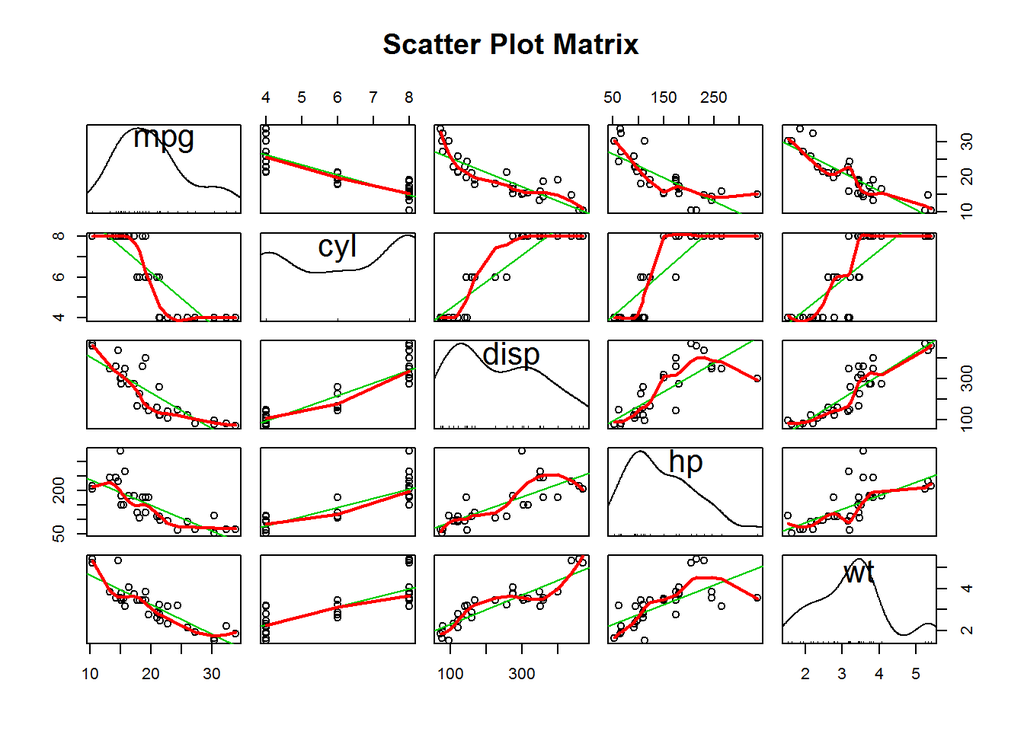

```r
scatterplotMatrix(mtcar, spread=FALSE, main="Scatter Plot Matrix")
```

```r
fit3 <- lm(mpg ~ hp + wt + hp:wt, data = mtcar)
summary(fit3)
```

```
##
## Call:
## lm(formula = mpg ~ hp + wt + hp:wt, data = mtcar)
##
## Residuals:
##    Min     1Q Median     3Q    Max
## -3.063 -1.649 -0.736  1.421  4.551
##
## Coefficients:
##             Estimate Std. Error t value Pr(>|t|)
## (Intercept) 49.80842    3.60516   13.82  5.0e-14 ***
## hp          -0.12010    0.02470   -4.86  4.0e-05 ***
## wt          -8.21662    1.26971   -6.47  5.2e-07 ***
## hp:wt        0.02785    0.00742    3.75  0.00081 ***
## ---
## Signif. codes:  0 '***' 0.001 '**' 0.01 '*' 0.05 '.' 0.1 ' ' 1
##
## Residual standard error: 2.15 on 28 degrees of freedom
## Multiple R-squared:  0.885,  Adjusted R-squared:  0.872
## F-statistic: 71.7 on 3 and 28 DF,  p-value: 2.98e-13
```

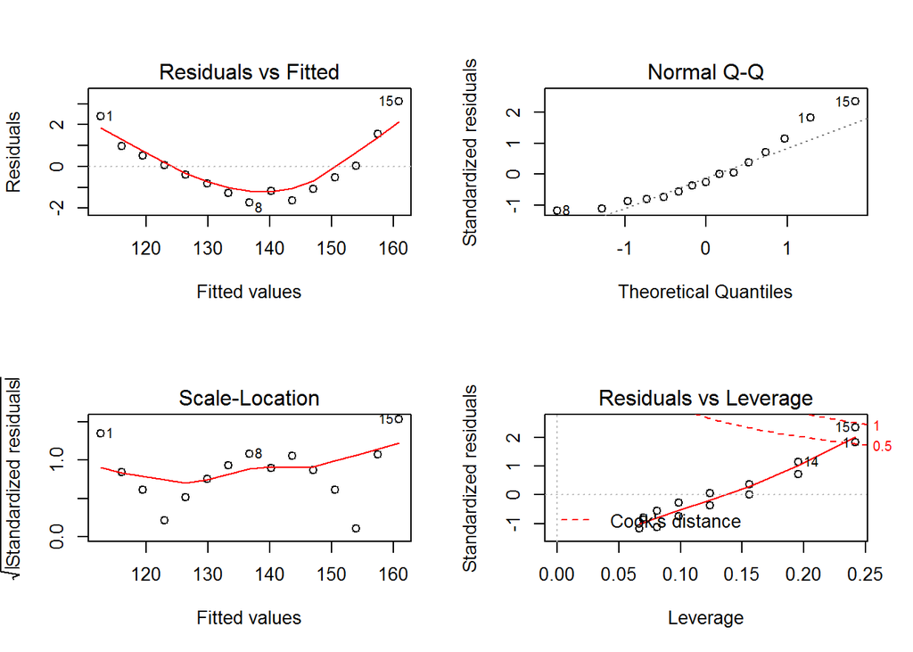

```r
fit <- lm(weight ~ height, data=women)
par(mfrow=c(2,2))
plot(fit)
```

残差图如果是左右开口的喇叭状很可能有异方差

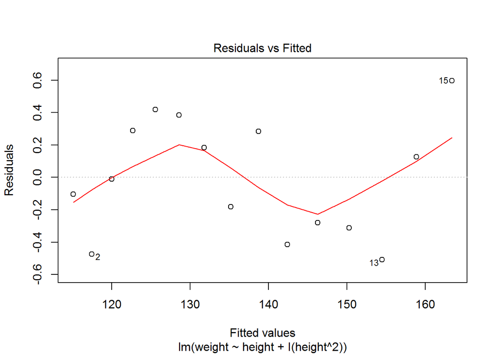

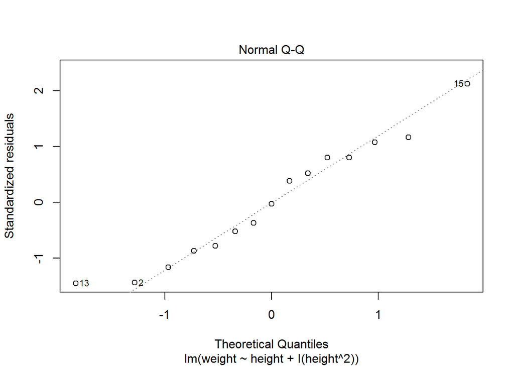

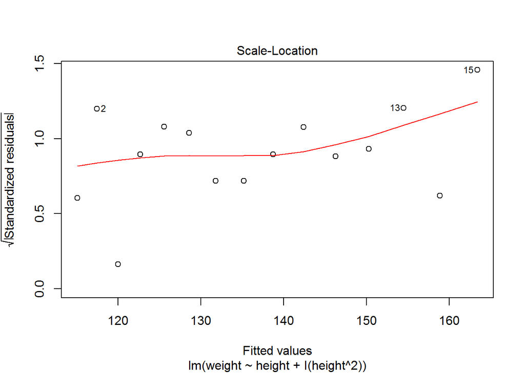

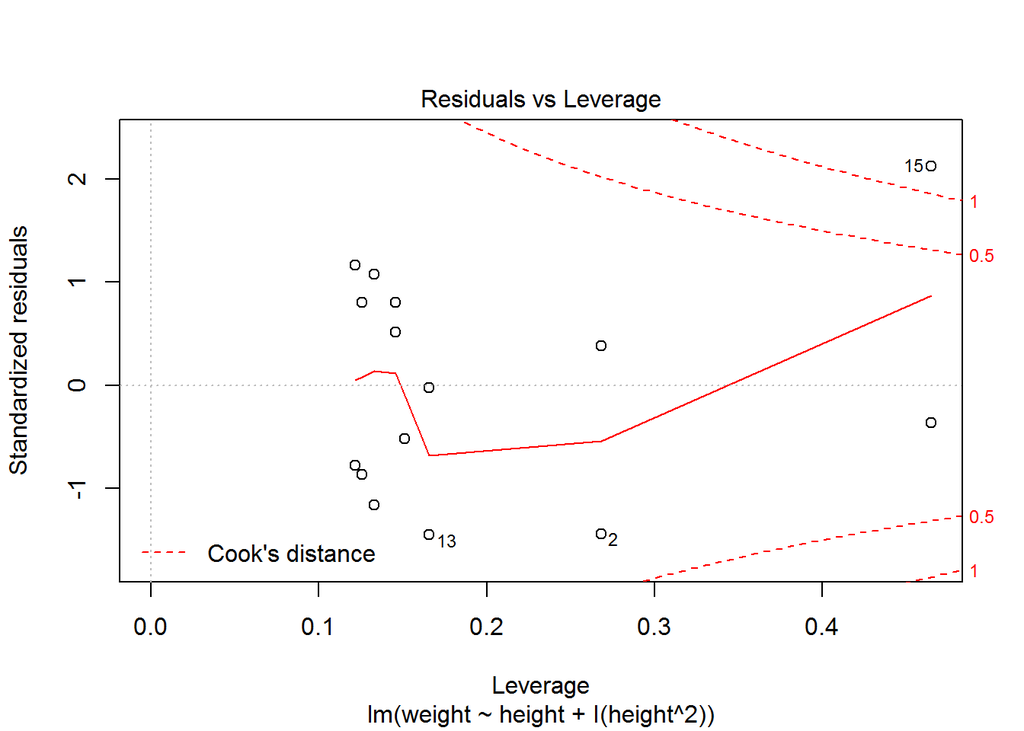

```r
#加入平方项回归
fit2 <- lm(weight ~ height + I(height^2), data=women)
plot(fit2)
```

## 系数之间相关影响实验

In order to explain the meaning of coefficients ,we have the following step.
Regression model:
$$y_i=\beta_0+\beta_1x_{i1}+\beta_2x_{i2}+u_i$$
Step 1:
$$w_i=y_i-\hat{\alpha}_0-\hat{\alpha}_1x_{i2}$$
Step 2:
$$v_i=x_{i1}-\hat{b}_0-\hat{b}_1x_{i2}$$
Step 3:
$$\bar{\beta}_1=\frac{\sum v_iw_i}{\sum v_i^{2}}$$

```r
mtcar <- as.data.frame(mtcars[,c("mpg", "cyl", "disp", "hp", "wt")])
fit <- lm(mpg~wt+disp, data=mtcar)
summary(fit)
```

```
##
## Call:
## lm(formula = mpg ~ wt + disp, data = mtcar)
##
## Residuals:
##    Min     1Q Median     3Q    Max
## -3.409 -2.324 -0.768  1.772  6.348
##
## Coefficients:
##             Estimate Std. Error t value Pr(>|t|)
## (Intercept) 34.96055    2.16454   16.15  4.9e-16 ***
## wt          -3.35083    1.16413   -2.88   0.0074 **
## disp        -0.01772    0.00919   -1.93   0.0636 .
## ---
## Signif. codes:  0 '***' 0.001 '**' 0.01 '*' 0.05 '.' 0.1 ' ' 1
##
## Residual standard error: 2.92 on 29 degrees of freedom
## Multiple R-squared:  0.781,  Adjusted R-squared:  0.766
## F-statistic: 51.7 on 2 and 29 DF,  p-value: 2.74e-10
```

```r
fit1 <- lm(mpg~disp, data=mtcar)
fit2 <- lm(wt~disp, data=mtcar)
fit3 <- lm(fit1$residuals~fit2$residuals-1)#没常数项用-1
summary(fit3)
```

```
##
## Call:
## lm(formula = fit1$residuals ~ fit2$residuals - 1)
##
## Residuals:
##    Min     1Q Median     3Q    Max
## -3.409 -2.324 -0.768  1.772  6.348
##
## Coefficients:
##                Estimate Std. Error t value Pr(>|t|)
## fit2$residuals    -3.35       1.13   -2.98   0.0056 **
## ---
## Signif. codes:  0 '***' 0.001 '**' 0.01 '*' 0.05 '.' 0.1 ' ' 1
##
## Residual standard error: 2.82 on 31 degrees of freedom
## Multiple R-squared:  0.222,  Adjusted R-squared:  0.197
## F-statistic: 8.86 on 1 and 31 DF,  p-value: 0.00562
```

说明x2对x1系数没有影响

## 置信区间

```r
mtcar <- as.data.frame(mtcars[,c("mpg", "cyl", "disp", "hp", "wt")])
mtcarn<-mtcar[order(mtcar$wt),]
fit <- lm(mpg~wt, data=mtcarn)
conf=predict(fit,interval="confidence",level=0.95)
conf
```

```
##                       fit   lwr  upr
## Lotus Europa        29.20 26.96 31.4
## Honda Civic         28.65 26.52 30.8
## Toyota Corolla      27.48 25.55 29.4
## Fiat X1-9           26.94 25.11 28.8
## Porsche 914-2       25.85 24.20 27.5
## Fiat 128            25.53 23.93 27.1
## Datsun 710          24.89 23.38 26.4
## Toyota Corona       24.11 22.72 25.5
## Mazda RX4           23.28 21.99 24.6
## Ferrari Dino        22.48 21.27 23.7
## Volvo 142E          22.43 21.22 23.6
## Mazda RX4 Wag       21.92 20.75 23.1
## Merc 230            20.45 19.35 21.6
## Ford Pantera L      20.34 19.24 21.4
## Merc 240D           20.24 19.14 21.3
## Hornet 4 Drive      20.10 19.00 21.2
## AMC Javelin         18.93 17.80 20.1
## Hornet Sportabout   18.90 17.77 20.0
## Merc 280            18.90 17.77 20.0
## Merc 280C           18.90 17.77 20.0
## Valiant             18.79 17.66 19.9
## Dodge Challenger    18.47 17.32 19.6
## Duster 360          18.21 17.03 19.4
## Maserati Bora       18.21 17.03 19.4
## Merc 450SL          17.35 16.10 18.6
## Merc 450SLC         17.08 15.81 18.4
## Camaro Z28          16.76 15.45 18.1
## Pontiac Firebird    16.74 15.42 18.0
## Merc 450SE          15.53 14.06 17.0
## Cadillac Fleetwood   9.23  6.66 11.8
## Chrysler Imperial    8.72  6.05 11.4
## Lincoln Continental  8.30  5.55 11.0
```

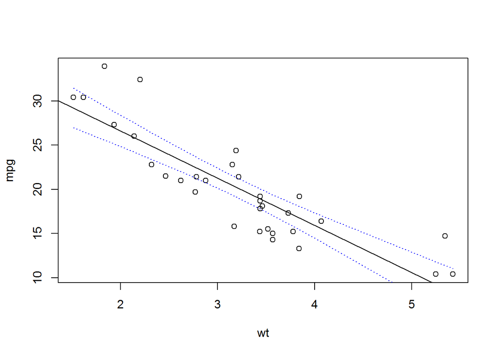

```r
plot(mpg~wt, data=mtcarn)
abline(fit)
lines(mtcarn$wt,conf[,2],lty=3,col="blue")
lines(mtcarn$wt,conf[,3],lty=3,col="blue")
```

## 假设检验

```r
mtcar <- as.data.frame(mtcars[,c("mpg", "cyl",
"disp", "hp", "wt")])
library(car)
fit <- lm(mpg ~ hp + wt, data = mtcar)
summary(fit)
```

```
##
## Call:
## lm(formula = mpg ~ hp + wt, data = mtcar)
##
## Residuals:
##    Min     1Q Median     3Q    Max
## -3.941 -1.600 -0.182  1.050  5.854
##
## Coefficients:
##             Estimate Std. Error t value Pr(>|t|)
## (Intercept) 37.22727    1.59879   23.28  < 2e-16 ***
## hp          -0.03177    0.00903   -3.52   0.0015 **
## wt          -3.87783    0.63273   -6.13  1.1e-06 ***
## ---
## Signif. codes:  0 '***' 0.001 '**' 0.01 '*' 0.05 '.' 0.1 ' ' 1
##
## Residual standard error: 2.59 on 29 degrees of freedom
## Multiple R-squared:  0.827,  Adjusted R-squared:  0.815
## F-statistic: 69.2 on 2 and 29 DF,  p-value: 9.11e-12
```

```r
linearHypothesis(fit, "hp = 0")#变量hp的系数=0
```

```
## Linear hypothesis test
##
## Hypothesis:
## hp = 0
##
## Model 1: restricted model
## Model 2: mpg ~ hp + wt
##
##   Res.Df RSS Df Sum of Sq    F Pr(>F)
## 1     30 278
## 2     29 195  1      83.3 12.4 0.0015 **
## ---
## Signif. codes:  0 '***' 0.001 '**' 0.01 '*' 0.05 '.' 0.1 ' ' 1
```

```r
linearHypothesis(fit, "hp = -0.5")
```

```
## Linear hypothesis test
##
## Hypothesis:
## hp = - 0.5
##
## Model 1: restricted model
## Model 2: mpg ~ hp + wt
##
##   Res.Df   RSS Df Sum of Sq    F Pr(>F)
## 1     30 18280
## 2     29   195  1     18085 2689 <2e-16 ***
## ---
## Signif. codes:  0 '***' 0.001 '**' 0.01 '*' 0.05 '.' 0.1 ' ' 1
```

```r
linearHypothesis(fit, "hp - wt= 0")#hp和wt相等
```

```
## Linear hypothesis test
##
## Hypothesis:
## hp - wt = 0
##
## Model 1: restricted model
## Model 2: mpg ~ hp + wt
##
##   Res.Df RSS Df Sum of Sq    F  Pr(>F)
## 1     30 439
## 2     29 195  1       244 36.3 1.5e-06 ***
## ---
## Signif. codes:  0 '***' 0.001 '**' 0.01 '*' 0.05 '.' 0.1 ' ' 1
```

F检验的f值，总是对应假设中T检验t值的平方（要在相同原假设下采用正确形式）